# IODS course project

## Part 4 - Creating Training and Test Sets

Now we need to scale the data. This is done by subtracting the column means from the corresponding columns and dividing the difference with standard deviation.
$$scaled(x)=\frac{x-mean(x)}{sd(x)}$$
The dataset is then standardized, and below I have printed out a summary of the scaled data.

```r
# center and standardize variables
boston_scaled <- scale(Boston)

# summaries of the scaled variables
summary(boston_scaled)
```

```
##       crim                 zn               indus
##  Min.   :-0.419367   Min.   :-0.48724   Min.   :-1.5563
##  1st Qu.:-0.410563   1st Qu.:-0.48724   1st Qu.:-0.8668
##  Median :-0.390280   Median :-0.48724   Median :-0.2109
##  Mean   : 0.000000   Mean   : 0.00000   Mean   : 0.0000
##  3rd Qu.: 0.007389   3rd Qu.: 0.04872   3rd Qu.: 1.0150
##  Max.   : 9.924110   Max.   : 3.80047   Max.   : 2.4202
##       chas              nox                rm               age
##  Min.   :-0.2723   Min.   :-1.4644   Min.   :-3.8764   Min.   :-2.3331
##  1st Qu.:-0.2723   1st Qu.:-0.9121   1st Qu.:-0.5681   1st Qu.:-0.8366
##  Median :-0.2723   Median :-0.1441   Median :-0.1084   Median : 0.3171
##  Mean   : 0.0000   Mean   : 0.0000   Mean   : 0.0000   Mean   : 0.0000
##  3rd Qu.:-0.2723   3rd Qu.: 0.5981   3rd Qu.: 0.4823   3rd Qu.: 0.9059
##  Max.   : 3.6648   Max.   : 2.7296   Max.   : 3.5515   Max.   : 1.1164
##       dis               rad               tax             ptratio
##  Min.   :-1.2658   Min.   :-0.9819   Min.   :-1.3127   Min.   :-2.7047
##  1st Qu.:-0.8049   1st Qu.:-0.6373   1st Qu.:-0.7668   1st Qu.:-0.4876
##  Median :-0.2790   Median :-0.5225   Median :-0.4642   Median : 0.2746
##  Mean   : 0.0000   Mean   : 0.0000   Mean   : 0.0000   Mean   : 0.0000
##  3rd Qu.: 0.6617   3rd Qu.: 1.6596   3rd Qu.: 1.5294   3rd Qu.: 0.8058
##  Max.   : 3.9566   Max.   : 1.6596   Max.   : 1.7964   Max.   : 1.6372
##      black             lstat              medv
##  Min.   :-3.9033   Min.   :-1.5296   Min.   :-1.9063
##  1st Qu.: 0.2049   1st Qu.:-0.7986   1st Qu.:-0.5989
##  Median : 0.3808   Median :-0.1811   Median :-0.1449
##  Mean   : 0.0000   Mean   : 0.0000   Mean   : 0.0000
##  3rd Qu.: 0.4332   3rd Qu.: 0.6024   3rd Qu.: 0.2683
##  Max.   : 0.4406   Max.   : 3.5453   Max.   : 2.9865
```

```r
# class of the boston_scaled object
class(boston_scaled)
```

```
## [1] "matrix"
```

```r
# change the object to data frame
boston_scaled <- as.data.frame(boston_scaled)
```

How did the variables change? They have changed per the *scaled(x)* equation above. It is worth noting that in this new summary, all the mean values are 0.

We can create a categorical variable from a continuous one, and we will do that with the crime rate in the Boston dataset (from the scaled crime rate). We will cut the `crim`variable by quantiles to get the high, low and middle rates of crime into their own categories. The quantiles are used as the break points in the new categorical variable. The old crime rate variable is dropped from the dataset.

```r
# summary of the scaled crime rate
summary(boston_scaled$crim)
```

```
##      Min.   1st Qu.    Median      Mean   3rd Qu.      Max.
## -0.419367 -0.410563 -0.390280  0.000000  0.007389  9.924110
```

```r
# create a quantile vector of crim and print it
bins <- quantile(boston_scaled$crim)
bins
```

```
##           0%          25%          50%          75%         100%
## -0.419366929 -0.410563278 -0.390280295  0.007389247  9.924109610
```

```r
# create a categorical variable 'crime'
crime <- cut(boston_scaled$crim, breaks = bins, include.lowest = TRUE, labels = c("low", "med_low", "med_high", "high"))

# look at the table of the new factor crime
table(crime)
```

```
## crime
##      low  med_low med_high     high
##      127      126      126      127
```

```r
# remove original crim from the dataset
boston_scaled <- dplyr::select(boston_scaled, -crim)

# add the new categorical value to scaled data
boston_scaled <- data.frame(boston_scaled, crime)
```

Next, we will divide the dataset to training and test sets, so that 80% of the data belongs to the training set.

```r
# number of rows in the Boston dataset
n <- nrow(boston_scaled)

# choose randomly 80% of the rows
ind <- sample(n,  size = n * 0.8)

# create train set
train <- boston_scaled[ind,]

# create test set
test <- boston_scaled[-ind,]

# save the correct classes from test data
correct_classes <- test$crime

# remove the crime variable from test data
test <- dplyr::select(test, -crime)
```

## Part 5 - Linear Discriminant Analysis

Next we will look at linear discriminant analysis. It is a classification and dimension reduction method that is closely related to logictic regression (from last week) and principal component analysis (next week). It can be used to find variables that discriminate or separate the classes best, or it can be used to predict the classes of new data.

First, we will fit the linear discriminant analysis on the training set created in the previous step. We will use the categorical crime rate as the target variable and all the other variables are predictor variables. Then we will draw the LDA (bi)plot.

```r
# linear discriminant analysis
lda.fit <- lda(crime ~ ., data = train)

# print the lda.fit object
lda.fit
```

```
## Call:
## lda(crime ~ ., data = train)
##
## Prior probabilities of groups:
##       low   med_low  med_high      high
## 0.2277228 0.2524752 0.2698020 0.2500000
##
## Group means:
##                   zn      indus        chas        nox          rm
## low       0.84754371 -0.9358969 -0.14394536 -0.8569049  0.35060897
## med_low  -0.07465284 -0.3467658 -0.07933396 -0.5972319 -0.13425586
## med_high -0.38339098  0.1601960  0.08887279  0.3558988  0.07792428
## high     -0.48724019  1.0171306 -0.11640431  1.0366684 -0.40576826
##                 age        dis        rad        tax     ptratio
## low      -0.8662374  0.8332688 -0.6797744 -0.7328290 -0.41425428
## med_low  -0.4000928  0.3839906 -0.5382477 -0.4409449 -0.07591744
## med_high  0.3668686 -0.3407652 -0.3971013 -0.3033034 -0.20914212
## high      0.7973996 -0.8573586  1.6379981  1.5139626  0.78062517
##                black        lstat        medv
## low       0.38591021 -0.744472527  0.44636193
## med_low   0.31289465 -0.157446865  0.01455462
## med_high  0.07873475 -0.002189037  0.13578677
## high     -0.93732374  0.927394381 -0.71386379
##
## Coefficients of linear discriminants:
##                 LD1         LD2         LD3
## zn       0.10906494  0.62377745 -1.13531612
## indus    0.05322299 -0.46536742  0.14773203
## chas    -0.13216034  0.03187179  0.14912357
## nox      0.38160116 -0.87143988 -1.31340196
## rm      -0.08408649 -0.16822375 -0.10507591
## age      0.27621431 -0.31288302 -0.12770212
## dis     -0.07285287 -0.27114158  0.22869227
## rad      3.02648456  0.83922961 -0.47961575
## tax     -0.07069070  0.24215369  1.04498472
## ptratio  0.12130243 -0.09199984 -0.32084668
## black   -0.14659440  0.01501370  0.09018636
## lstat    0.17181941 -0.11250985  0.54368077
## medv     0.15063945 -0.43352627 -0.01423253
##
## Proportion of trace:
##    LD1    LD2    LD3
## 0.9434 0.0422 0.0144
```

Now, I will try to explain the above LDA model output with the help of a very useful video that can be found [here](https://player.vimeo.com/video/203184662). Look for the part starting at 02:46.

First at the top we have the prior probabilities of groups. These are simply the number of observations in each class divided by the number of observations in the whole dataset.

The group means have the value for every variable and for every class. The means differ between the classes.

Then there are the coefficients of the linear discriminants. There is a coefficient for each of the variables. We have four target variables, and therefore three linear discriminants.

The proportion of trace is the between-group variance. In our model, Linear Discriminant 1 explains almost 95% of the between-group variance.

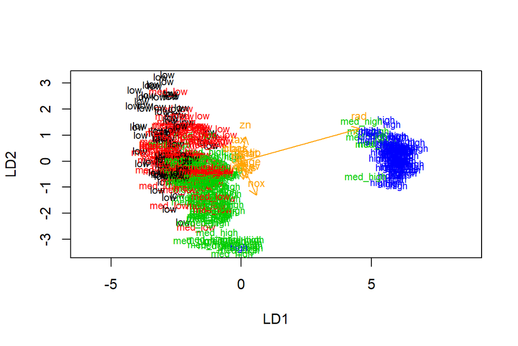

```r
# the function for lda biplot arrows
lda.arrows <- function(x, myscale = 1, arrow_heads = 0.1, color = "orange", tex = 0.75, choices = c(1,2)){
  heads <- coef(x)
  arrows(x0 = 0, y0 = 0,
         x1 = myscale * heads[,choices[1]],
         y1 = myscale * heads[,choices[2]], col=color, length = arrow_heads)
  text(myscale * heads[,choices], labels = row.names(heads),
       cex = tex, col=color, pos=3)
}

# target classes as numeric
classes <- as.numeric(train$crime)

# plot the lda results
plot(lda.fit, dimen = 2, col = classes, pch = classes)
lda.arrows(lda.fit, myscale = 1.5)
```

## Part 6 - Predict with the LDA Model

The data was split earlier so that we now have the test set and the correct class labels. Now we will predict the classes with the LDA model on the test data. Based on the trained model, LDA calculates the probabilites for the new observation for belonging in each of the classes. The observation is classified to the class of the highest probability. The probabilities are estimated using Bayes Theorem.

The results are cross tabulated with the crime categories from the test set.

Save the crime categories from the test set and then remove the categorical crime variable from the test dataset

```r
# predict classes with test data
lda.pred <- predict(lda.fit, newdata = test)

# cross tabulate the results
tt <- table(correct = correct_classes, predicted = lda.pred$class)
tt
```

```
##           predicted
## correct    low med_low med_high high
##   low       22       9        4    0
##   med_low    3      14        7    0
##   med_high   0       5       12    0
##   high       0       0        0   26
```

```r
error = sum(tt[row(tt) != col(tt)]) / sum(tt)
error
```

```
## [1] 0.2745098
```

```r
summary(test)
```

```
##        zn              indus               chas              nox
##  Min.   :-0.4872   Min.   :-1.44698   Min.   :-0.2723   Min.   :-1.4040
##  1st Qu.:-0.4872   1st Qu.:-1.02061   1st Qu.:-0.2723   1st Qu.:-0.9602
##  Median :-0.4872   Median :-0.19558   Median :-0.2723   Median :-0.2994
##  Mean   : 0.2024   Mean   : 0.01256   Mean   : 0.2295   Mean   :-0.0367
##  3rd Qu.: 0.3703   3rd Qu.: 1.01499   3rd Qu.:-0.2723   3rd Qu.: 0.5981
##  Max.   : 3.8005   Max.   : 2.42017   Max.   : 3.6648   Max.   : 2.7296
##        rm                age                  dis
##  Min.   :-3.87641   Min.   :-2.3331282   Min.   :-1.23124
##  1st Qu.:-0.39657   1st Qu.:-0.9804980   1st Qu.:-0.80430
##  Median : 0.00052   Median : 0.5284441   Median :-0.38628
##  Mean   : 0.13654   Mean   :-0.0002229   Mean   : 0.07754
##  3rd Qu.: 0.68332   3rd Qu.: 0.8774813   3rd Qu.: 0.83025
##  Max.   : 3.44336   Max.   : 1.1163897   Max.   : 3.28405
##       rad                tax              ptratio
##  Min.   :-0.98187   Min.   :-1.30676   Min.   :-2.70470
##  1st Qu.:-0.63733   1st Qu.:-0.82022   1st Qu.:-0.85708
##  Median :-0.52248   Median :-0.56508   Median : 0.06673
##  Mean   :-0.04621   Mean   :-0.07307   Mean   :-0.09992
##  3rd Qu.: 1.20022   3rd Qu.: 1.52941   3rd Qu.: 0.80578
##  Max.   : 1.65960   Max.   : 1.79642   Max.   : 1.63721
##      black             lstat               medv
##  Min.   :-3.9033   Min.   :-1.35737   Min.   :-1.66713
##  1st Qu.: 0.2488   1st Qu.:-0.86655   1st Qu.:-0.48741
##  Median : 0.3882   Median :-0.33791   Median :-0.06337
##  Mean   : 0.1830   Mean   :-0.08703   Mean   : 0.14460
##  3rd Qu.: 0.4254   3rd Qu.: 0.48409   3rd Qu.: 0.54008
##  Max.   : 0.4406   Max.   : 2.54261   Max.   : 2.98650
```

## Part 7 - K-means Algorithm

Now we will look at clusterin, and we will start with distance measures. First, we need to reload the Boston dataset and standardize the dataset.

```r
library(MASS)
data('Boston')
```

Now we will scale the `Boston`variables to get comparable distances.

```r
# center and standardize variables
boston_K_scaled <- scale(Boston)

# summaries of the scaled variables
summary(boston_K_scaled)
```

```
##       crim                 zn               indus
##  Min.   :-0.419367   Min.   :-0.48724   Min.   :-1.5563
##  1st Qu.:-0.410563   1st Qu.:-0.48724   1st Qu.:-0.8668
##  Median :-0.390280   Median :-0.48724   Median :-0.2109
##  Mean   : 0.000000   Mean   : 0.00000   Mean   : 0.0000
##  3rd Qu.: 0.007389   3rd Qu.: 0.04872   3rd Qu.: 1.0150
##  Max.   : 9.924110   Max.   : 3.80047   Max.   : 2.4202
##       chas              nox                rm               age
##  Min.   :-0.2723   Min.   :-1.4644   Min.   :-3.8764   Min.   :-2.3331
##  1st Qu.:-0.2723   1st Qu.:-0.9121   1st Qu.:-0.5681   1st Qu.:-0.8366
##  Median :-0.2723   Median :-0.1441   Median :-0.1084   Median : 0.3171
##  Mean   : 0.0000   Mean   : 0.0000   Mean   : 0.0000   Mean   : 0.0000
##  3rd Qu.:-0.2723   3rd Qu.: 0.5981   3rd Qu.: 0.4823   3rd Qu.: 0.9059
##  Max.   : 3.6648   Max.   : 2.7296   Max.   : 3.5515   Max.   : 1.1164
##       dis               rad               tax             ptratio
##  Min.   :-1.2658   Min.   :-0.9819   Min.   :-1.3127   Min.   :-2.7047
##  1st Qu.:-0.8049   1st Qu.:-0.6373   1st Qu.:-0.7668   1st Qu.:-0.4876
##  Median :-0.2790   Median :-0.5225   Median :-0.4642   Median : 0.2746
##  Mean   : 0.0000   Mean   : 0.0000   Mean   : 0.0000   Mean   : 0.0000
##  3rd Qu.: 0.6617   3rd Qu.: 1.6596   3rd Qu.: 1.5294   3rd Qu.: 0.8058
##  Max.   : 3.9566   Max.   : 1.6596   Max.   : 1.7964   Max.   : 1.6372
##      black             lstat              medv
##  Min.   :-3.9033   Min.   :-1.5296   Min.   :-1.9063
##  1st Qu.: 0.2049   1st Qu.:-0.7986   1st Qu.:-0.5989
##  Median : 0.3808   Median :-0.1811   Median :-0.1449
##  Mean   : 0.0000   Mean   : 0.0000   Mean   : 0.0000
##  3rd Qu.: 0.4332   3rd Qu.: 0.6024   3rd Qu.: 0.2683
##  Max.   : 0.4406   Max.   : 3.5453   Max.   : 2.9865
```

```r
# class of the boston_scaled object
class(boston_K_scaled)
```

```
## [1] "matrix"
```

```r
# change the object to data frame
boston_K_scaled <- as.data.frame(boston_K_scaled)
```

Now we will calculate the distances between the observations. We will use the `dist()`function for this, and by default it will use Euclidean distance measure to create a distance matrix. We will also look at the Manhattan method.

```r
# euclidean distance matrix
dist_eu <- dist(boston_K_scaled)

# look at the summary of the distances
summary(dist_eu)
```

```
##    Min. 1st Qu.  Median    Mean 3rd Qu.    Max.
##  0.1343  3.4625  4.8241  4.9111  6.1863 14.3970
```

```r
# manhattan distance matrix
dist_man <- dist(boston_K_scaled, method = 'manhattan')

# look at the summary of the distances
summary(dist_man)
```

```
##    Min. 1st Qu.  Median    Mean 3rd Qu.    Max.
##  0.2662  8.4832 12.6090 13.5488 17.7568 48.8618
```

K-means is one of the best known clustering methods, and it is an unsupervised one. It assigns obsrvations to clusters based on the similarities of the objects. We will next run a k-means algorithm on the dataset. We will use 4 centers to begin with. This could in theory be any number though, hence the K.

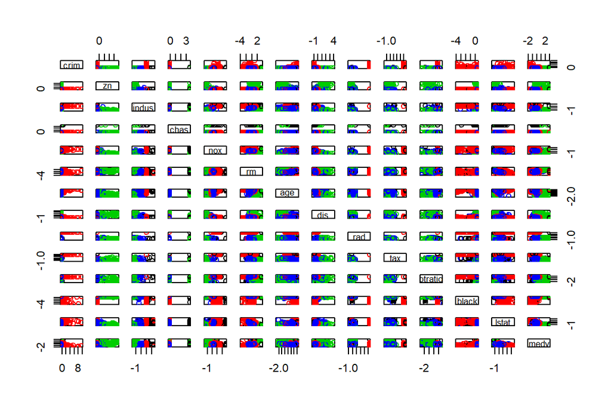

```r
# k-means clustering
km <-kmeans(boston_K_scaled, centers = 4)

# plot the Boston dataset with clusters
pairs(boston_K_scaled, col = km$cluster)
```

But now the question arises: what is the optimal number of clusters? In other words, we need to determine the K. There are more than one way to skin the proverbial cat here, but we will look at how the total of *within cluster sum of squares* or WCSS behaves when we change the number of clusters. The WCSS is calculated as follows:

$WCSS=\sum^N_{i} (X_i-centroid)^2$